# MTH6139 Time Series

Coursework 1 – Exploring a Time Series for monthly Airline Passenger numbers between 1949-1960

Milan Kalpesh Thanki (220368496)

Spring term 2025

# 1.Introduction

I’ve decided to analyse the post-war monthly air passenger numbers from **1949-1960**. Throughout my analysis, I am aiming to use the dataset to understand *linear trends*, *seasonality* and *forecasting*, as well as identifying any trends that can impact further predicative analysis.

# 2. Overview of the dataset

```r
AirPassengers
```

```
##      Jan Feb Mar Apr May Jun Jul Aug Sep Oct Nov Dec
## 1949 112 118 132 129 121 135 148 148 136 119 104 118
## 1950 115 126 141 135 125 149 170 170 158 133 114 140
## 1951 145 150 178 163 172 178 199 199 184 162 146 166
## 1952 171 180 193 181 183 218 230 242 209 191 172 194
## 1953 196 196 236 235 229 243 264 272 237 211 180 201
## 1954 204 188 235 227 234 264 302 293 259 229 203 229
## 1955 242 233 267 269 270 315 364 347 312 274 237 278
## 1956 284 277 317 313 318 374 413 405 355 306 271 306
## 1957 315 301 356 348 355 422 465 467 404 347 305 336
## 1958 340 318 362 348 363 435 491 505 404 359 310 337
## 1959 360 342 406 396 420 472 548 559 463 407 362 405
## 1960 417 391 419 461 472 535 622 606 508 461 390 432
```

```r
head(AirPassengers,12)
```

```
##  [1] 112 118 132 129 121 135 148 148 136 119 104 118
```

From using `head(AirPassengers,12)`, we can display that there are **12 months** of values, and **12 years** of data, thus producing a total of **144 data points** to analyse.

From only looking at the first row, there are *clear seasonal fluctuations* - passenger numbers are ‘higher in the summer months’, and ‘lower in the winter period’.

# 3. Data Analysis and Summary

Before creating a time series, I’ve aimed to visualise general trends in the number of passengers over time, as well as provide a summary where we are able to detect any outliers and unusual patterns that we can examine further.

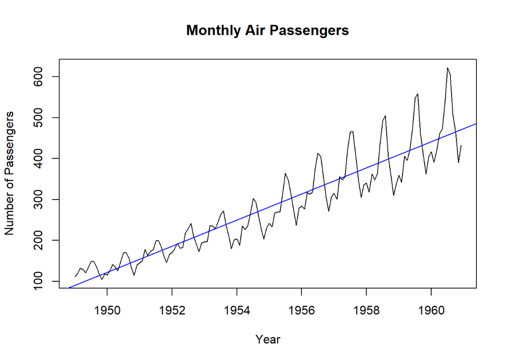

```r
original_model <- lm(AirPassengers ~ time(AirPassengers))

plot(AirPassengers, main = 'Monthly Air Passengers',
     xlab = 'Year', ylab = 'Number of Passengers')

abline(original_model, col = 'blue')
```

As we can see above, the plot (with a line of best fit) shows a distinct **upwards trend** in the number of air passengers over the 12 years in which the data was recorded. This may be due to an increase in demand for *air travel*, as well as improvements in both *economic growth* globally and *technological advances*.

As well as this, factors such as *school vacations* and *favourable weather conditions* in certain months are shown in the spikes on the plot.

```r
summary(AirPassengers)
```

```
##    Min. 1st Qu.  Median    Mean 3rd Qu.    Max.
##   104.0   180.0   265.5   280.3   360.5   622.0
```